# RIRO (v.1.0) - Российский индекс научных организаций

Лутай А.В. (РФФИ, [orcid](https://orcid.org/0000-0003-1341-781X))

Стерлигов И.А. (НИУ ВШЭ, [orcid](https://orcid.org/0000-0001-9736-4713))

22.05.2021

## Что такое RIRO?

RIRO - это проект Russian Index of the Research Organizations, запущенный в мае 2021 года. RIRO v.1.0 - представляет из себя набор таблиц, которые связывают российские юридические лица, задействованные в научных исследованиях, с идентификаторами и профилями российских и международных информационных систем:

- [Wikidata](https://www.wikidata.org/)
- [ROR](https://ror.org/)
- [GRID](https://www.grid.ac/)
- [Microsoft Academic](https://academic.microsoft.com/home)
- [Scopus](https://www.elsevier.com/solutions/scopus)
- [SciVal](https://www.elsevier.com/solutions/scival)
- [Web of Science](https://clarivate.com/webofsciencegroup)
- [InCites](https://clarivate.com/webofsciencegroup/solutions/incites/)
- [Мониторинг вузов Минобрнауки](https://monitoring.miccedu.ru/?m=vpo).

Все версии датасета будут доступны на Zenodo: https://zenodo.org/communities/riro/.

Фрагменты кода и примеры использования будут выкладываться на GitHub: https://github.com/OpenRIRO.

## Зачем всё это?

Основная цель создания RIRO – открыть и связать профили и идентификаторы российских научных организаций в информационных системах. Объединение и соотнесение данных из этих систем необходимо как для изучения, так и для управления сетью организаций на современном этапе развития науки и данных о ней.

Работа по созданию RIRO заключается далеко не только в механическом соединении источников. У каждого из существующих идентификаторов свои "детские болезни": одни стараются быстро реагировать на переименования и реорганизации, но полностью переписывают историю со всеми правопредшественниками; другие, напротив, привязываются к "славным" именам мифических героев, которые уже не актуальны. В результате одна организация в различных сервисах может быть представлена совершенно различными наборами идентификаторов, что уменьшает и без этого ограниченную применимость наукометрических инструментов для анализа российской науки.

Опубликованный датасет нацелен на решение следующих задач:

- предоставить в распоряжение исследователей наборы идентификаторов, учитывающих особенности структуры и истории трансформации российских научных организаций.
- отразить актуальность и полноту сведений о российских научных организациях в проприетарных и открытых сервисах.
- привлечь внимание исследователей к возможностях новых информационно-аналитических сервисов.
- выбранный подход – публикация только идентификаторов и профилей, но не самих показателей – позволяет открыто объединить разнообразные источники данных из коммерческих и некоммерческих, российских и иностранных систем.

## Датасет

Набор таблиц можно скачать с Zenodo вручную или программой, используя [OAI-PMH Harvesting API](https://zenodo.org/oai2d?verb=ListRecords&set=user-riro&metadataPrefix=oai_dc) или [REST API](https://developers.zenodo.org/). Zenodo – один из ведущих репозиториев данных открытой науки, развиваемый на базе ЦЕРН ([подробнее](https://help.zenodo.org/features/)).

Датасет состоит из отдельных таблиц в стандартном формате CSV (может быть открыт в Excel и любых программах по работе с данными), связанных через идентификатор code, который выступает в роли первичного ключа.

Ниже будут показаны фрагменты каждой таблицы с информацией о 3 учреждениях, выбранных в качестве примера:

- ФИЦ КОМИ НЦ УРО РАН
- ТОМСКИЙ НИМЦ
- РТУ МИРЭА

## Таблица 1. Официальные сведения об организациях.

Содержит официальные сведения об организации - ОГРН, ИНН/КПП, полное и краткое названия, тип (головное, филиал или представительство) и статус (активное, ликвидировано или в стадии реорганизации).

В таблице ниже для экономии места краткие названия не приведены.

| code | level | status | name_full | ogrn | inn | kpp |
| --- | --- | --- | --- | --- | --- | --- |
| n4p9t7 | Head | Действующая организация | ФЕДЕРАЛЬНОЕ ГОСУДАРСТВЕННОЕ БЮДЖЕТНОЕ УЧРЕЖДЕНИЕ НАУКИ ФЕДЕРАЛЬНЫЙ ИССЛЕДОВАТЕЛЬСКИЙ ЦЕНТР КОМИ НАУЧНЫЙ ЦЕНТР УРАЛЬСКОГО ОТДЕЛЕНИЯ РОССИЙСКОЙ АКАДЕМИИ НАУК | 1021100511332 | 1101481574 | 110101001 |
| w6n9h2 | Head | Действующая организация | ФЕДЕРАЛЬНОЕ ГОСУДАРСТВЕННОЕ БЮДЖЕТНОЕ НАУЧНОЕ УЧРЕЖДЕНИЕ ТОМСКИЙ НАЦИОНАЛЬНЫЙ ИССЛЕДОВАТЕЛЬСКИЙ МЕДИЦИНСКИЙ ЦЕНТР РОССИЙСКОЙ АКАДЕМИИ НАУК | 1027000861568 | 7019011979 | 701701001 |
| i7x2s7 | Branch | Действующая организация | ТЮМЕНСКИЙ КАРДИОЛОГИЧЕСКИЙ НАУЧНЫЙ ЦЕНТР - ФИЛИАЛ ФЕДЕРАЛЬНОГО ГОСУДАРСТВЕННОГО БЮДЖЕТНОГО НАУЧНОГО УЧРЕЖДЕНИЯ ТОМСКИЙ НАЦИОНАЛЬНЫЙ ИССЛЕДОВАТЕЛЬСКИЙ МЕДИЦИНСКИЙ ЦЕНТР РОССИЙСКОЙ АКАДЕМИИ НАУК | 1027000861568 | 7019011979 | 720343001 |
| y5b3t9 | Head | Действующая организация | ФЕДЕРАЛЬНОЕ ГОСУДАРСТВЕННОЕ БЮДЖЕТНОЕ ОБРАЗОВАТЕЛЬНОЕ УЧРЕЖДЕНИЕ ВЫСШЕГО ОБРАЗОВАНИЯ МИРЭА - РОССИЙСКИЙ ТЕХНОЛОГИЧЕСКИЙ УНИВЕРСИТЕТ | 1037739552740 | 7729040491 | 772901001 |
| s8t3r2 | Branch | Действующая организация | ФИЛИАЛ ФЕДЕРАЛЬНОГО ГОСУДАРСТВЕННОГО БЮДЖЕТНОГО ОБРАЗОВАТЕЛЬНОГО УЧРЕЖДЕНИЯ ВЫСШЕГО ОБРАЗОВАНИЯ МИРЭА - РОССИЙСКИЙ ТЕХНОЛОГИЧЕСКИЙ УНИВЕРСИТЕТ В Г. СТАВРОПОЛЕ | 1037739552740 | 7729040491 | 263543001 |
| r2i9t5 | Branch | Действующая организация | ФИЛИАЛ ФЕДЕРАЛЬНОГО ГОСУДАРСТВЕННОГО БЮДЖЕТНОГО ОБРАЗОВАТЕЛЬНОГО УЧРЕЖДЕНИЯ ВЫСШЕГО ОБРАЗОВАНИЯ МИРЭА - РОССИЙСКИЙ ТЕХНОЛОГИЧЕСКИЙ УНИВЕРСИТЕТ В Г. ФРЯЗИНО МОСКОВСКОЙ ОБЛАСТИ | 1037739552740 | 7729040491 | 505203001 |

Поиск по таблице выполнялся по значениям ОГРН, поэтому в таблице появилис также действующие филиалы, но каждая строка (запись) имеет свой собственный уникальный код (поле code), который и выступает связующим звеном (ключом) между таблицами.

## Таблица 2. Адреса и геоданные

В этой таблице по значениям code можно найти полный адрес организации (или филиала), отдельные фрагменты адреса, а также код geocode, временной пояс и географические координаты. В примере приведены данные для всех записей, приведенных в таблице выше.

| code | geoname_id | lat | lon | time | federal_district | address_full | postal_code | region_type | region | city | settlement_type | settlement | street_type | street | house_type | house | block_type_full | block |
| --- | --- | --- | --- | --- | --- | --- | --- | --- | --- | --- | --- | --- | --- | --- | --- | --- | --- | --- |
| n4p9t7 | 485239 | 61.6660239 | 50.8235666 | UTC+3 | Северо-Западный | 167982, РЕСПУБЛИКА КОМИ, ГОРОД СЫКТЫВКАР, УЛИЦА КОММУНИСТИЧЕСКАЯ, ДОМ 24 | 167000 | республика | Коми | Сыктывкар |  |  | улица | Коммунистическая | дом | 24 |  |  |
| w6n9h2 | 1489425 | 56.490009 | 84.9458326 | UTC+7 | Сибирский | 634009, ОБЛАСТЬ ТОМСКАЯ, ГОРОД ТОМСК, ПЕРЕУЛОК КООПЕРАТИВНЫЙ, 5 | 634009 | область | Томская | Томск |  |  | переулок | Кооперативный | дом | 5 |  |  |
| i7x2s7 | 1488754 | 57.134939 | 65.5663861 | UTC+5 | Уральский | 625026, ОБЛАСТЬ ТЮМЕНСКАЯ, ГОРОД ТЮМЕНЬ, УЛИЦА МЕЛЬНИКАЙТЕ, ДОМ 111 | 625026 | область | Тюменская | Тюмень |  |  | улица | Мельникайте | дом | 111 |  |  |
| y5b3t9 | 524901 | 55.6733309 | 37.4801249 | UTC+3 | Центральный | 119454, ГОРОД МОСКВА, ПРОСПЕКТ ВЕРНАДСКОГО, 78 | 119454 | город | Москва | Москва |  |  | проспект | Вернадского | дом | 78 |  |  |
| s8t3r2 | 487846 | 45.0521865 | 41.9126233 | UTC+3 | Северо-Кавказский | 355035, КРАЙ СТАВРОПОЛЬСКИЙ, ГОРОД СТАВРОПОЛЬ, ПРОСПЕКТ КУЛАКОВА, ДОМ 8, КВ-Л 601 | 355035 | край | Ставропольский | Ставрополь |  |  | проспект | Кулакова | дом | 8 |  |  |
| r2i9t5 | 562319 | 55.9657426 | 38.0488063 | UTC+3 | Центральный | 141190, ОБЛАСТЬ МОСКОВСКАЯ, ГОРОД ФРЯЗИНО, УЛИЦА ВОКЗАЛЬНАЯ, ДОМ 2А | 141190 | область | Московская | Фрязино |  |  | улица | Вокзальная | дом | 2А |  |  |

Таблица 2 - единственная(!) таблица, которая имеет уникальное соответствие с таблицей 1 (по полю code), по сути это продолжение таблицы 1. Во всех остальных таблицах одному коду (code) могут соответствовать несколько строк.

## Таблица 3 - Иерархия

Данная таблица связывает существующие головные организации с филиалами и правопредшественниками (для удобства в этом документе они обозначены как "дочерние организации").

Таблица не является абсолютно полной, но для большинства научных организаций включает в себя включает все официальные филиалы и представительства (на момент сборки), а также правопредшественников последней реорганизации. Для некоторых учреждений (например, больниц) в таблице присутствуют только головные учреждения.

Столбцы code относятся к головной организации, child_code - это code для дочерних организаций, relation - тип отношения (2 значения - "Филиал" или "Правопредшественники").

| code | child_code | relation |
| --- | --- | --- |
| y5b3t9 | s8t3r2 | Филиал |
| y5b3t9 | r2i9t5 | Филиал |
| y5b3t9 | p5p5p9 | Правопредшественники |
| y5b3t9 | n2b3b6 | Правопредшественники |
| y5b3t9 | w3s9x4 | Правопредшественники |
| y5b3t9 | v8s5p4 | Правопредшественники |
| y5b3t9 | g8i5z7 | Правопредшественники |
| y5b3t9 | x3b5x3 | Правопредшественники |
| y5b3t9 | t5m2v3 | Правопредшественники |
| y5b3t9 | g5w8g3 | Правопредшественники |

[output cut: 29 more lines]

Итак, используя список из 3 ОГРН, мы из таблицы 1, извлекли 6 code, по которым в таблице 3 извлекли дополнительные code для правопредшественников, получим в итоге значений 42 "объекта" с уникальными значениями code.

Соберем теперь группы вида: {code головной организации} - {все родственные коды} - {отношение}.

| parent_code | Головная | Филиал | Правопредшественники |
| --- | --- | --- | --- |
| n4p9t7 | 1 | 0 | 9 |
| w6n9h2 | 1 | 1 | 6 |
| y5b3t9 | 1 | 2 | 21 |

Несмотря на то, что все найденные в таблице 3 дочерние организации также содержатся в таблице 1, легко найти в последней удастся только филиалы (они имеют одинаковые значения ОГРН и ИНН с головной организацией). Поэтому, если Вас интересуют только головные учреждения или филиалы, но не правопредшественники, Вы можете использовать для поиска только таблицу 1.

Однако, не спешите закрывать документ, ниже мы покажем, какую роль в RIRO играют правопредшественники и почему не стоит игнорировать таблицу 3.

## Таблица 4 - ROR

Research Organizations Registry – стартовавший в 2019 г. международный общественный проект по созданию открытой базы уникальных идентификаторов научных организаций, по смыслу близкий проекту ORCID для отдельных ученых, построенный с использованием наработок аналогичного проекта GRID (Global Research Identifier Database). Идентификаторы ROR открыто доступны для скачивания как в виде [датасета](https://figshare.com/collections/ROR_Data/4596503), так и через [API](https://github.com/ror-community/ror-api). Любой может предложить дополнение или исправление в ROR.

Таблица содержит записи из БД ROR, которым найдено соответствие в БД RuoR (ключ code).

| code | ror_id | grid | ror_name | ror_name_rus | ror_relationships | ror_city | ror_links | ror_aliases | ror_acronyms | ror_status | ror_wikipedia | ror_isni | ror_orgref | ror_wikidata |
| --- | --- | --- | --- | --- | --- | --- | --- | --- | --- | --- | --- | --- | --- | --- |
| n4p9t7 | 04ggfw624 | grid.473258.f | Institute of Chemistry, Komi Science Center | Коми научный центр УрО РАН | label:Department of Chemistry and Material Sciences\|type:Parent\|id:https://ror.org/059tqvg48 | Syktyvkar | http://chemi.komisc.ru/en/ | Komi SC |  | active |  | 0000 0000 9097 8504 |  |  |
| n4p9t7 | 01tpj7340 | grid.501775.1 | Institute of Geology, Komi Science Centre | Институт геологии Коми НЦ УрО РАН | label:Ural Branch of the Russian Academy of Sciences\|type:Parent\|id:https://ror.org/02s4h3z39 | Syktyvkar | http://geo.komisc.ru/en/ | Institute of Geology, Komi Science Centre, Russian Mineralogical Society |  | active |  |  |  |  |
| t5p4t4 | 00029be75 | grid.483432.a | Institute of Biology of Komi Scientific Centre | Института биологии Коми НЦ УрО РАН | label:Russian Academy of Sciences\|type:Parent\|id:https://ror.org/05qrfxd25 | Syktyvkar | http://ib.komisc.ru/en/ | nstitute of Biology of Komi Scientific Centre of the Ural Branch of the Russian Academy of Sciences | IB Komi SC UB RAS | active |  |  |  |  |
| r2r5g5 | 02k9pct19 | grid.494805.4 | Institute of Physiology, Komi Science Center | Институт экологической физиологии Уральского отделения | label:Ural Branch of the Russian Academy of Sciences\|type:Parent\|id:https://ror.org/02s4h3z39 | Syktyvkar | http://physiol.komisc.ru |  |  | active |  | 0000 0004 0399 5250 |  |  |
| w6n9h2 | 01z0w8p93 | grid.473330.0 | Tomsk National Research Medical Center | Томский национальный исследовательский медицинский центр | label:Russian Academy of Sciences\|type:Parent\|id:https://ror.org/05qrfxd25 | Tomsk | http://www.tnimc.ru/en/ |  | TNRMC | active |  |  |  |  |
| w6n9h2 | 05gf3n961 | grid.452262.5 | Tomsk Cancer Research Institute | Томский научно-исследовательский институт онкологии | label:Department of Medical Sciences\|type:Parent\|id:https://ror.org/019zcmj26 | Tomsk | http://www.oncology.tomsk.ru/english/ | Federal State Scientific Institution "Tomsk Research Institute of Oncology" |  | active |  |  |  |  |
| b6h7x5 | 044171329 | grid.465396.b | Research Institute of Pharmacology and Regenerative Medicine named ED Goldberg | Научно-исследовательский институт фармакологии и регенеративной медицины имени Е.Д. Гольдберга | label:Department of Medical Sciences\|type:Parent\|id:https://ror.org/019zcmj26 | Tomsk | http://www.pharmso.ru/ | Federal State Scientific Institution "Research Institute of Pharmacology name ED Goldberg"\|Research Institute of Pharmacology and Regenerative Medicine name ED Goldberg Russian Academy of Medical Sci… | NIIFiRM\|НИИФиРМ | active |  | 0000 0004 4657 0877 |  |  |
| h2v5i8 | 029k7k053 | grid.465310.5 | Research Institute of Medical Genetics of Russian Academy of Medical Sciences | Научно-исследовательский институт медицинской генетики | label:Department of Medical Sciences\|type:Parent\|id:https://ror.org/019zcmj26 | Tomsk | http://www.medgenetics.ru/english/ | Federal State Scientific Institution "Research Institute of Medical Genetics," the Siberian Branch of the Russian Academy of Medical Sciences |  | active |  | 0000 0004 0620 3511 |  |  |
| y6t2i3 | 01sb2fs58 | grid.418894.8 | Institute of Cardiology | Федеральное государственное бюджетное научное учреждение Научно-исследовательский институт кардиологии | label:Department of Medical Sciences\|type:Parent\|id:https://ror.org/019zcmj26 | Tomsk | http://cardio-tomsk.ru/ | Federal State Scientific Institution Research Institute of Cardiology |  | active |  | 0000 0004 0381 144X |  |  |
| x9n5h2 | 026md7341 | grid.465327.1 | Research Institute of Mental Health | Федеральное государственное бюджетное научное учреждение Научно-исследовательский институт психического здоровья | label:Department of Medical Sciences\|type:Parent\|id:https://ror.org/019zcmj26 | Tomsk | http://www.mental-health.ru/ | Federal State Institution "Research Institute of Mental Health" of the Siberian Branch of the Russian Academy of Medical Sciences |  | active |  |  |  |  |

[output cut: 2 more lines]

Некоторые записи в поле Relationships содержат композитную строку следующего вида:

`label:xxxx|type:yyyyyy|id:https://ror.org/zzzzz`

которая содержит 3 компонента label (название), type (тип отношений) и id (ROR идентификатор) для организации, которая *по мнению создателей ROR* имеет отношение искомой.

Таблица 5. Wikidata

WikiData – общественный репозиторий всевозможных структурированных характеристик разнообразных объектов (в нашем случае – научных организаций), дополнять и редактировать которые может любой. Данные из WikiData доступны открыто через разнообразные интерфейсы.

Важно понимать, что обилие информации в WikiData (от профилей в twitter до списка ректоров) внесено разнообразными людьми без системной верификации и нередко содержит неточности и неофициальную информацию.

Таблица содержит фрагменты записей из БД Wikidata, которым было найдено соответствие в реестре RuoR.

| code | wikidata | wd_itemlabel | wd_rus_orgname | wd_eng_orgname | wd_web_site | wikipedia_eng | wikipedia_rus | wd_itemaltlabel | wd_altlabel | wd_oldnames | wd_isni | wd_elibrary | wd_grid | wd_ror | wd_google | wd_mag | wd_qs | wd_the | wd_ria | wd_umultirank | wd_arwu | wd_cr_funder | wd_doi_pref | wd_twitter | wd_facebook | wd_twitter_id | wd_youtube |
| --- | --- | --- | --- | --- | --- | --- | --- | --- | --- | --- | --- | --- | --- | --- | --- | --- | --- | --- | --- | --- | --- | --- | --- | --- | --- | --- | --- |
| n4p9t7 | Q4229557 | Institute of Chemistry, Komi Science Center | Коми научный центр УрО РАН | Institute of Chemistry, Komi Science Center | chemi.komisc.ru |  |  | Komi SC... | Коми научный центр РАН... |  | 0000 0000 9097 8504 |  | grid.473258.f | 04ggfw624 |  |  |  |  |  |  |  |  |  |  |  |  |  |
| n4p9t7 | Q61931541 | Institute of Geology Komi SC UB RAS | Институт геологии Коми НЦ УрО РАН | Institute of Geology Komi SC UB RAS | geo.komisc.ru |  |  | IG KSC UB RAS, Institute of Geology KSC ... | Институт геологии Коми научного центра У... |  |  |  | grid.501775.1 | 01tpj7340 |  |  |  |  |  |  |  |  |  |  |  |  |  |
| t5p4t4 | Q33121401 | Institute of Biology of Komi Scientific Centre | Института биологии Коми НЦ УрО РАН | Institute of Biology of Komi Scientific Centre | ib.komisc.ru |  |  | IB Komi SC UB RAS, Institute of Biology ... |  |  |  |  | grid.483432.a | 00029be75 |  |  |  |  |  |  |  |  |  |  |  |  |  |
| b6h7x5 | Q30263248 | Research Institute of Pharmacology and Regenerative Medicine named ED Goldberg | Научно-исследовательский институт фармакологии и регенеративной медицины имени Е.Д. Гольдберга | Research Institute of Pharmacology and Regenerative Medicine named ED Goldberg | pharmso.ru |  |  | Federal State Scientific Institution "Re... |  |  | 0000 0004 4657 0877 |  | grid.465396.b | 44171329 |  |  |  |  |  |  |  |  |  |  |  |  |  |
| h2v5i8 | Q30263200 | Research Institute of Medical Genetics of Russian Academy of Medical Sciences | Научно-исследовательский институт медицинской генетики | Research Institute of Medical Genetics of Russian Academy of Medical Sciences | medgenetics.ru |  |  | Federal State Scientific Institution "Re... |  |  | 0000 0004 0620 3511 |  | grid.465310.5 | 029k7k053 |  |  |  |  |  |  |  |  |  |  |  |  |  |
| y6t2i3 | Q4310643 | Institute of Cardiology | НИИ кардиологии ТНЦ СО РАМН | Institute of Cardiology | cardio-tomsk.ru |  |  | Federal State Scientific Institution Res... | Федеральное государственное бюджетное на... |  | 0000 0004 0381 144X |  | grid.418894.8 | 01sb2fs58 |  |  |  |  |  |  |  |  |  |  |  |  |  |
| y5b3t9 | Q3272997 | Moscow State Institute of Radio-engineering Electronics and Automation | МИРЭА | Moscow State Institute of Radio-engineering Electronics and Automation | mirea.ru | https://en.wikipedia.org/wiki/Moscow_Tec... | https://ru.wikipedia.org/wiki/%D0%9C%D0%... | MIREA - Russian Technological University... | Московский институт радиотехники, электр... |  | 0000 0000 9620 717X |  | grid.466477.0 | 04qrtgy16 | /m/03y0ffn | 48336290 |  |  |  |  |  |  |  | mirea_ru |  | 920936018 | UCZA93tbfBUK-ow2NkEshAqg |
| n2b3b6 | Q4304105 | Moscow State University of Instrument Engineering and Computer Science | Московский государственный университет приборостроения и информатики | Moscow State University of Instrument Engineering and Computer Science | old.mgupi.ru | https://en.wikipedia.org/wiki/Moscow_Sta... | https://ru.wikipedia.org/wiki/%D0%9C%D0%... |  | Московский технологический университет (... |  |  |  |  |  | /m/05f3bs6 | 98594063 |  |  |  |  |  |  |  |  |  |  |  |
| z7p3b7 | Q4304107 | Moscow State University of Fine Chemical Technologies | Московский государственный университет тонких химических технологий имени М. В. Ломоносова | Moscow State University of Fine Chemical Technologies | mitht.ru | https://en.wikipedia.org/wiki/Moscow_Sta... | https://ru.wikipedia.org/wiki/%D0%9C%D0%... | Moscow State University of Fine Chemical... | Московский технологический университет (... |  | 0000 0004 0645 9576 |  | grid.419325.8 | 04aty2659 |  | 208875869 |  |  |  |  |  |  |  |  |  |  |  |

## Таблица 6 Scopus

Scopus – одна из ведущих мировых баз научного цитирования, аккумулирующая метаданные научных публикаций из десятков тысяч журналов и конференций, а также части книг. Большинство государственных научно-образовательных организаций России имеет к ней доступ в рамках национальной подписки. В рамках этого стандартного доступа всем желающим без дополнительной платы доступен и полноценный [API-интерфейс](https://dev.elsevier.com/scopus.html), к которому доступны дружелюбные для неискушенных пользователей API-обертки (wrapper) на [python](https://pybliometrics.readthedocs.io/en/stable/) и [R](https://github.com/muschellij2/rscopus), в которых есть функции для сбора информации по идентификаторам организаций.

Таблица содержит идентфикаторы Scopus, которым было найдено соответствие в БД RIRO.

Обращаем внимание, что соответствие профилей организациям определялось по названиям первых и данная таблица не гарантирует полноту или безошибочность их наполнения в Scopus. Приведенное в таблице количество публикаций соответствовало действительности на момент сбора данных (апрель-май 2021).

О том, как корректировать профиль организации в Scopus можно прочесть на [русскоязычном сайте Elsevier](https://elsevierscience.ru/products/scopus/).

| code | scopus_id | scopus_affil_name | scopus_affil_name_variants | scopus_affil_city | scopus_affil_country | scopus_affil_pubs |
| --- | --- | --- | --- | --- | --- | --- |
| n4p9t7 | 60004454 | Komi Science Centre Ural Division, Russian Academy of Sciences | Russian Academy Of Sciences | Syktyvkar | Russian Federation | 2425 |
| t5p4t4 | 60105357 | Institute of Biology of the Komi Science Centre of the Ural Branch of the Russian Academy of Sciences | Russian Academy Of Sciences | Syktyvkar | Russian Federation | 1204 |
| x4x3v2 | 60110362 | Institute of Socio- Economic &amp; Energy Problems of North of the Komi Science Centre of the Ural Branch of the Russian Academy of Sciences | Institute Of Socio-economic And Energy Problems Of The North | Syktyvkar | Russian Federation | 45 |
| t6y7n3 | 60110359 | Institute of Chemistry of the Komi Science Centre of the Ural Branch of the Russian Academy of Sciences | Institute Of Chemistry | Syktyvkar | Russian Federation | 656 |
| r2r5g5 | 60110361 | Institute of Physiology of the Komi Scientific Center of the Ural Branch of the Russian Academy of Sciences | Institute Of Physiology | Syktyvkar | Russian Federation | 434 |
| h4p9g9 | 60105307 | Institute of Geology of the Komi Science Centre of the Ural Branch of the Russian Academy of Sciences | Institute Of Geology | Syktyvkar | Russian Federation | 710 |
| n7n4z6 | 60110360 | Institute of Language, Literature and History of the Komi Science Centre of the Ural Branch of the Russian Academy of Sciences | Institute Of Language, Literature And History | Syktyvkar | Russian Federation | 66 |
| n7n4z6 | 123297935 | Literature and History Komi Science Centre of the Russian Academy of Science | Literature And History Komi Science Centre Of The Russian Academy Of Science |  | Russian Federation | 1 |
| w6n9h2 | 60072487 | Tomsk National Research Medical Center, Russian Academy of Sciences | Russian Academy Of Medical Sciences | Tomsk | Russian Federation | 1453 |
| w6n9h2 | 60108892 | Cancer Research Institute, Tomsk National Research Medical Center, Russian Academy of Sciences | Cancer Research Institute | Tomsk | Russian Federation | 736 |

[output cut: 10 more lines]

## Таблица 7. Microsoft Academic

[Microsoft Academic Graph](https://www.microsoft.com/en-us/research/project/microsoft-academic-graph/) (MAG) – проект исследовательского подразделения Microsoft по созданию базы научного цитирования и метаданных на основе информации, собираемой парсерами Bing с сайтов журналов и PDF-файлов ([подробнее](https://docs.microsoft.com/en-us/academic-services/project-academic-knowledge/introduction)). В этом заключается главное отличие MAG от Web of Science и Scopus, которые получают информацию от издателей.

За счет сочетания открытости и сбора роботом MAG является уникальным источником, особенно в «горячей» и приоритетной области Computer Science, и основой для ряда инструментов нового поколения ([Lens](https://www.lens.org/), [Semantic Scholar](https://www.semanticscholar.org/), [Open Academic Graph](https://www.microsoft.com/en-us/research/project/open-academic-graph/)).

Несмотря на последние новости о [прекращении работы Microsoft Academic](https://www.microsoft.com/en-us/research/project/academic/articles/microsoft-academic-to-expand-horizons-with-community-driven-approach/), было принято решение включить идентификаторы MAG в RIRO. Есть вероятность, что проект MAG в силу своей большой значимости для инфраструктуры открытой науки будет перезапущен сообществом.

| code | mag_id | mag_orgname |
| --- | --- | --- |
| y5b3t9 | 48336290 | moscow state institute of radio engineering electronics and automation |
| n2b3b6 | 98594063 | moscow state university of instrument engineering and computer science |
| z7p3b7 | 208875869 | moscow state university of fine chemical technologies |

## Таблица 8 - InCites

InCites – аналитическая надстройка над базой Web of Science Core Collection, доступная части российских вузов. К сожалению, в системе нет API-интерфейса для сбора показателей по организациям, но они доступны для ручного скачивания и связывания с другими данными через название, которое и служит «идентификатором».

В таблице приведены официальные названия организации в БД Web of Science и InCites.

| code | incites_orgname | wos_orgname | wos_pubs_2019_21 |
| --- | --- | --- | --- |
| n4p9t7 | Komi Science Centre of the Ural Branch of the Russian Academy of Sciences | Komi Science Centre Of The Ural Branch Of The Russian Academy Of Sciences | 599 |
| t5p4t4 | Institute of Biology, Komi Scientific Centre, Ural Branch RAS | Institute Of Biology Komi Scientific Centre Ural Branch Ras | 275 |
| t6y7n3 | Institute of Chemistry, Komi Scientific Centre, Ural Branch RAS | Institute Of Chemistry Komi Scientific Centre Ural Branch Ras | 149 |
| r2r5g5 | Institute of Physiology, Komi Scientific Center of the Russian Academy of Sciences | Institute Of Physiology Komi Scientific Center Of The Russian Academy Of Sciences | 70 |
| h4p9g9 | Institute of Geology, Komi Scientific Centre of the Russian Academy of Sciences | Institute Of Geology Komi Scientific Centre Of The Russian Academy Of Sciences | 122 |
| w6n9h2 | Tomsk National Research Medical Center | Tomsk National Research Medical Center | 628 |
| b6h7x5 | E. D. Goldberg Research Institute of Pharmacology & Regenerative Medicine | E D Goldberg Research Institute Of Pharmacology Regenerative Medicine | 79 |
| y6t2i3 | Cardiology Research Institute - Tomsk | Cardiology Research Institute Tomsk | 204 |
| h2z9t3 | Research Institute of Obstetrics, Gynecology & Perinatology - Tomsk |  |  |
| y5b3t9 | MIREA - Russian Technological University | Mirea Russian Technological University | 978 |

[output cut: 1 more lines]

## Таблица 9 - SciVal

В таблице приведены официальное название и уникальный идентификатор организации в БД SciVal.

| code | scival_id | scival_institution_name |
| --- | --- | --- |
| t6y7n3 | 719642 | Institute of Chemistry |
| w6n9h2 | 719242 | RAS - Tomsk National Research Medical Сепtеr |
| b6h7x5 | 719248 | RAS - Goldberg Research Institute of Pharmacology and Regenerative Medicine |
| y6t2i3 | 719244 | RAS - Cardiology Research lnstitute, Tomsk National Research Medical Center |
| y5b3t9 | 708852 | Moscow Technological University |

## Таблица 10 - Мониторинг эффективности вузов Минобрнауки (1-Мониторинг)

Мониторинг эффективности вузов Минобрнауки – основной национальный сбор данных всевозможной информации о работе вузов, включает все организации высшего образования, кроме относящихся к силовым ведомствам.

Идентификатор в системе мониторинга однозначно указывает на URL открытой веб-страницы с данными о кадрах, финансовой информации, студентах и аспирантах, недвижимости и многом другом, что является очень ценным в соотнесении с данными из других таблиц.

| code | monitoring_id |
| --- | --- |
| y5b3t9 | 134 |
| s8t3r2 | 14013186 |
| r2i9t5 | 14013178 |

## Таблица 11 - Web of Science

Web of Science – старейшая и наиболее известная в мире наукометрическая база данных, доступная для большинства научно-образовательных организаций России в рамках национальной подписки.

В настоящий момент Web of Science не предоставляет пользователям уникальные идентификаторы организаций, вместо них используются «официальные» варианты названий, но ситуация осложняется тем, что вместе с ними существует и множество неофициальных. И те, и другие представлены в таблице 11 в том виде, в котором они встречаются в результатах поиска в интерфейсе онлайн-сервиса Web of Science.

Все эти варианты можно использовать для автоматизации процессов сбора сведений о публикациях с участием организаций (через выгрузку вариантов названий из модуля analyze results с последующим сопоставлением вариантов названий с теми, что присутствуют в таблице 11.

К моменту запуска релиза 1.0 мы распознали лишь часть названий. Надеемся, что нам удастся увеличить количество строк в этой таблице в следующих релизах.

К сожалению, в рамках централизованной подписки на Web of Science доступ к API-интерфейсам для выгрузки информации об организациях не предоставлен.

| code | wos_name_variant | wos_main | wos_incites_main_name |
| --- | --- | --- | --- |
| n4p9t7 | Komi Science Centre Of The Ural Branch Of The Russian Academy Of Sciences | YES | Komi Science Centre Of The Ural Branch Of The Russian Academy Of Sciences |
| t5p4t4 | Institute Of Biology Komi Scientific Centre Ural Branch Ras | YES | Institute Of Biology Komi Scientific Centre Ural Branch Ras |
| t6y7n3 | Institute Of Chemistry Komi Scientific Centre Ural Branch Ras | YES | Institute Of Chemistry Komi Scientific Centre Ural Branch Ras |
| r2r5g5 | Institute Of Physiology Komi Scientific Center Of The Russian Academy Of Sciences | YES | Institute Of Physiology Komi Scientific Center Of The Russian Academy Of Sciences |
| h4p9g9 | Inst Geol Komi Sci Ctr Ub Ras | NO | Institute Of Geology Komi Scientific Centre Of The Russian Academy Of Sciences |
| h4p9g9 | Institute Of Geology Komi Scientific Centre Of The Russian Academy Of Sciences | YES | Institute Of Geology Komi Scientific Centre Of The Russian Academy Of Sciences |
| n7n4z6 | Inst Language Literature Hist Komi Sc Ub Ras | n\a | n\a |
| n7n4z6 | Institute Of Language Literature History Komi Scientific Centre Of The Ras | n\a | n\a |
| w6n9h2 | Canc Res Inst Tomsk Nmrc | NO | Tomsk National Research Medical Center |
| w6n9h2 | Canc Res Inst Tomsk Nrmc | NO | Tomsk National Research Medical Center |

[output cut: 23 more lines]

## Все идентификаторы для 3 организаций

На иллюстрации ниже для выбранных организаций показано как идентификаторы зарубежных сервисов (ROR, GRID, Scopus Affiliation ID, InCites ID, MAG, Wikidata) и российского оператора (Мониторинг) соответствуют головным организациям, их филиалам и правопредшественникам.

Группы идентификаторов для каждой организации представлены в виде блоков (по горизонтали). В каждом блоке на оси X расположены идентификаторам, по оси Y - сами организации, их филиалы и правпредшественники. Для каждого идентификатора показан тип организации.

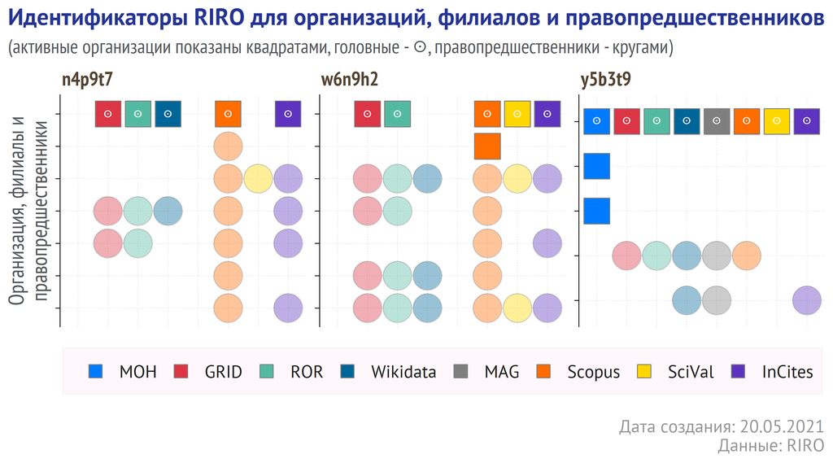

## Общая картина

На иллюстрации ниже показано соотношение разных идентификаторов в RIRO (v.1.0).

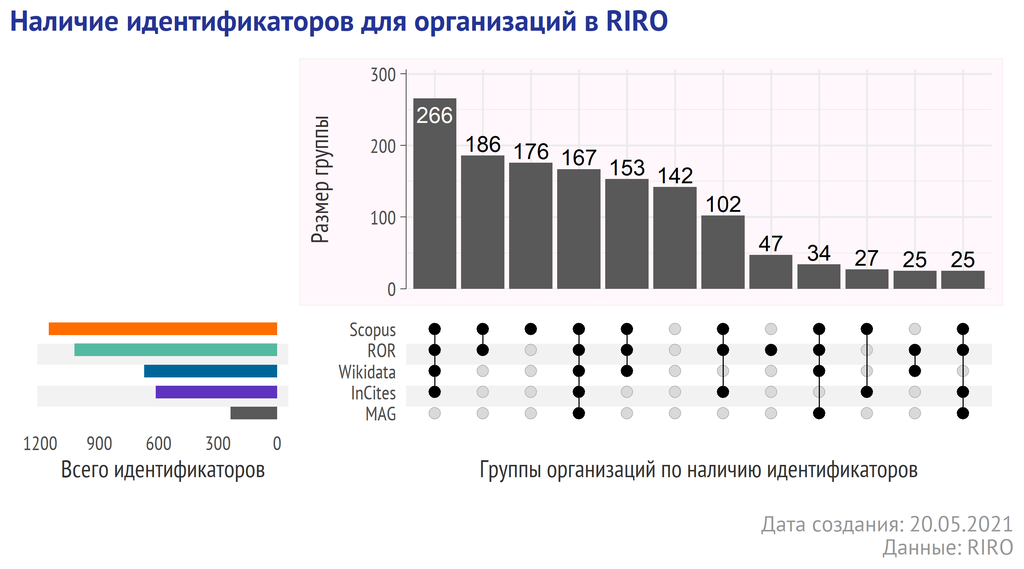

## Примечания

- Таблицы RIRO содержат не все поля из оригинальных баз данных.
- Содержимое столбцов в таблицах 4-11 соответствует тому, что находится в базах данных.
- Некоторые таблицы содержат похожие поля. Например, в таблице 4 (ROR) у организаций есть идентификатор Wikidata (ror_wikidata), а в таблице 5 (Wikidata) - идентификатор ROR (wd_ror). Соответствие этих данных друг другу не проверялось.
- Соответствие каждого идентификатора определенной российской организации было сделано, исходя из имеющихся данных (совпадение названия и города). 100% корректность не гарантирована.

## Обратная связь

Форма для [обратной связи](https://forms.gle/Y9S6UZDmYpCyRRKe8) предусматривает следующие варианты:

- Обновить официальные сведения об организации (филиале, представительстве)
- Добавить новую организацию (в текущей версии отсутствует)
- Исправить соответствие организаций и идентификаторов (ROR, GRID, Wikidata и др.)
- Добавить новые соответствия в имеющиеся таблицы
- Предложить новый источник данных

Ваши замечания и предложения помогут улучшить RIRO.

Отчет выполнен с использованием [R v4.0.0](https://www.r-project.org/), [RStudio v1.2.5042](https://www.rstudio.com/) и программных пакетов:

- [DT](https://rstudio.github.io/DT/)
- [tidyverse](https://www.tidyverse.org/).